# Script No. 3

Marlene Kammerer

18 Oktober 2023

# Network positions, roles, and characteristics

## Tutorial

### Content

Well known already!!

- Load packages
- Load the network data
- Create network objects
- Add actor attributes
- Plot networks using centrality and actor type (–> we use a new package)

NEW - Assortativity (Looking for homophily) - Finding Bridges - A package to identify structural holes

### Install & load packages

Again, we work with the`igraph` package. But also with several other packages … if you don’t have them yet installed, do so!

```r
# install.packages("migraph") # to install the package
library(igraph) # to load the package
```

### Load the network data

We will work again with the Swiss dataset. Since this is all well-known already. We do this VERY quickly now. Attention! We work with one new dataset, the two-level dataset.

Hence, we have several datasets:

- A dataset that contains information in the organization name and it’s type (covariate)
- A dataset that contains information on the beliefs, instrument preferences, and secondary aspects that an actor holds (also covariates)
- A dataset that contains information on whether an actors is involved as well at the level of international climate politics

Have a look at these datasets and try to understand what all these variables mean!

```r
## Attributes

beliefs.Ch <- read.csv2("Data/CH_beliefs.csv", header=TRUE, fileEncoding = "latin1", stringsAsFactors = FALSE)
twolevel.ch <- read.csv2("Data/CH_2level.csv", header=TRUE, fileEncoding = "latin1", stringsAsFactors = FALSE)

## Collaboration network

coll.ch <- read.csv2("Data/cH_coll.csv", header=TRUE)
rownames(coll.ch) <- coll.ch$X
coll.ch$X <- NULL

## Influence network

inf.ch <- read.csv2("Data/cH_influence.csv", header=TRUE)
rownames(inf.ch) <- inf.ch$X
inf.ch$X <- NULL

## Actor type

types.ch <- read.csv2("Data/CH_type.csv", header = TRUE, fileEncoding = "latin1", stringsAsFactors = FALSE)
```

### Create network objects

As usual we have to create network objects! This time, we only work with the collaboration network. We directly add the type variable and the organization name to the network.

```r
coll.ch.mat <- as.matrix(coll.ch) # transform dataset into matrix format
coll.ch.net <- graph.adjacency(coll.ch.mat, mode="directed", diag=FALSE) # transform matrix into graph object
V(coll.ch.net)$type <- types.ch$Type
V(coll.ch.net)$klar <- types.ch$Klarname_EN
list.vertex.attributes(coll.ch.net)
```

```
## [1] "name" "type" "klar"
```

### Plot network

We plot the collaboration network. This time using a new package. To do so, we need to transform the the igraph object into a tidygraph object.

Here is a nice tutorial on tidy graph: https://tidygraph.data-imaginist.com/reference/group_graph.html

Just by looking at the network, I can already understand a lot about the position of different actors in a network.

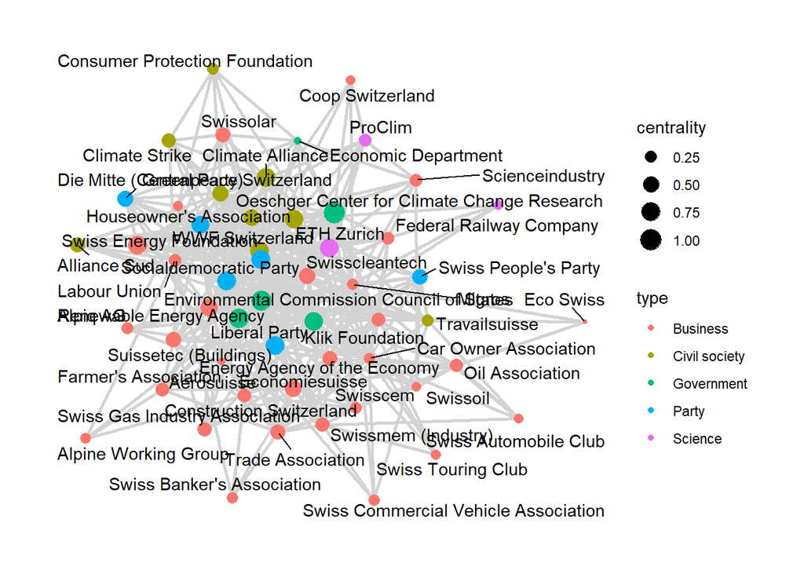

```r
library(tidygraph)
library(ggraph)

coll.ch.tidy <- as_tbl_graph(coll.ch.net)

set.seed(123)

coll.ch.tidy %>%
  activate(nodes) %>%
  mutate(centrality = centrality_authority()) %>% # to display node size based on degree centrality
  ggraph(layout = "graphopt") +
  geom_edge_link(width = 1, colour = "lightgray") +
  geom_node_point(aes(size = centrality, colour = type)) +
  geom_node_text(aes(label = klar), repel = TRUE)+
  # scale_color_gradient(low = "yellow", high = "red")+
  theme_graph()
```

```r
ggsave("Plots/Climate_pol_net.png", dpi=300)
```

### What do key actors think about climate policy?

Previously, we have learnt to investigate basic network structures, to identify the most central, i.e., important or influential actors and we have added some network characteristics to the network.

We have seen, that this allows us to understand, which group of actors, e.g. governmental actors, is more or less central in a network.

We can do the same thing for other characteristics as well!

Let’s try to see what key actors in Switzerland think about *Carbon Pricing*!

The result is not so clear – > core actors seem to deviate!

```r
library(tidyverse)

# First calculate the centralization statistics as ususal ...

myCentrality <- function(net) {

  if (!is.igraph(net)) stop ("Input is not an igraph object")
  ideg <- degree (net, mode="in", loop=F, normalized = T)
  odeg <- degree (net, mode="out", loop=F, normalized = T)
  btw <- betweenness (net, normalized=TRUE)
  clo <- closeness (net, normalized=TRUE) # consider removing
  evc <- evcent(net)$vector
  id <- V(net)

  ret <-data.frame (cbind(IDegree=ideg, ODegree=odeg,
                         Betweenness=btw, Closeness=clo,
                          Eigenvector=evc, ID=id))
  return(ret)

}

Results_coll <- myCentrality(coll.ch.net)
Results_coll
```

```
##         IDegree    ODegree Betweenness Closeness Eigenvector ID
## CH1  0.03773585 0.24528302 0.001286312 0.5638298  0.33069409  1
## CH2  0.22641509 0.41509434 0.046410645 0.6162791  0.72313079  2
## CH3  0.13207547 0.00000000 0.000000000       NaN  0.20840614  3
## CH4  0.07547170 0.11320755 0.000919846 0.5000000  0.25418455  4
## CH5  0.09433962 0.37735849 0.020017163 0.6162791  0.41176613  5
## CH6  0.15094340 0.11320755 0.011305792 0.4344262  0.19933685  6
## CH7  0.13207547 0.22641509 0.008961296 0.4907407  0.35410727  7
## CH8  0.37735849 0.00000000 0.000000000       NaN  0.44670370  8
## CH9  0.24528302 0.20754717 0.026468495 0.5463918  0.45239373  9
## CH10 0.20754717 0.30188679 0.027268280 0.5578947  0.41625542 10
## CH11 0.24528302 0.13207547 0.027616553 0.4308943  0.42812989 11
## CH12 0.24528302 0.22641509 0.015727083 0.5463918  0.57950849 12
## CH13 0.16981132 0.30188679 0.007297836 0.5698925  0.62098163 13
## CH14 0.07547170 0.15094340 0.005427697 0.4529915  0.19063075 14
## CH15 0.24528302 0.24528302 0.017188600 0.5196078  0.56942704 15
## CH16 0.11320755 0.13207547 0.001613431 0.4690265  0.32990094 16
## CH17 0.32075472 0.67924528 0.120409980 0.7571429  1.00000000 17
## CH18 0.07547170 0.39622642 0.014784040 0.5578947  0.35757018 18
## CH19 0.07547170 0.09433962 0.001702346 0.3212121  0.19211670 19
## CH20 0.09433962 0.16981132 0.004426132 0.5145631  0.33384085 20
## CH21 0.11320755 0.13207547 0.021803188 0.4690265  0.27319858 21
## CH22 0.07547170 0.01886792 0.000359965 0.3212121  0.09911998 22
## CH23 0.22641509 0.01886792 0.000750743 1.0000000  0.35998625 23
## CH24 0.20754717 0.15094340 0.016018648 0.4953271  0.31944745 24
## CH25 0.09433962 0.30188679 0.006117415 0.5353535  0.44169072 25
## CH26 0.24528302 0.35849057 0.021476161 0.6091954  0.74926576 26
## CH27 0.03773585 0.18867925 0.001831295 0.5300000  0.22838317 27
## CH28 0.15094340 0.18867925 0.010318719 0.5247525  0.32620983 28
## CH29 0.16981132 0.05660377 0.003908572 0.7142857  0.25884949 29
## CH30 0.20754717 0.35849057 0.040512702 0.6022727  0.69624807 30
## CH31 0.15094340 0.20754717 0.011323342 0.4862385  0.34062070 31
## CH32 0.05660377 0.15094340 0.001344469 0.4649123  0.15979727 32
## CH33 0.09433962 0.13207547 0.010074284 0.4453782  0.21452314 33
## CH34 0.13207547 0.18867925 0.006888137 0.5463918  0.34209476 34
## CH35 0.18867925 0.32075472 0.017490115 0.5824176  0.67056038 35
## CH36 0.22641509 0.22641509 0.009228357 0.5463918  0.61761377 36
## CH37 0.26415094 0.50943396 0.042665214 0.6708861  0.91158346 37
## CH38 0.28301887 0.35849057 0.035906290 0.5955056  0.66433671 38
## CH39 0.22641509 0.33962264 0.018194743 0.5824176  0.63503550 39
## CH40 0.32075472 0.03773585 0.005377013 1.0000000  0.34587633 40
## CH41 0.35849057 0.00000000 0.000000000       NaN  0.36111686 41
## CH42 0.18867925 0.00000000 0.000000000       NaN  0.17875071 42
## CH43 0.20754717 0.00000000 0.000000000       NaN  0.20656507 43
## CH44 0.15094340 0.00000000 0.000000000       NaN  0.12249327 44
## CH45 0.09433962 0.00000000 0.000000000       NaN  0.09453956 45
## CH46 0.11320755 0.00000000 0.000000000       NaN  0.10664825 46
## CH47 0.18867925 0.00000000 0.000000000       NaN  0.18168593 47
## CH48 0.15094340 0.00000000 0.000000000       NaN  0.16634006 48
## CH49 0.09433962 0.00000000 0.000000000       NaN  0.06448682 49
## CH50 0.09433962 0.00000000 0.000000000       NaN  0.08665339 50
## CH51 0.09433962 0.00000000 0.000000000       NaN  0.08570753 51
## CH52 0.09433962 0.00000000 0.000000000       NaN  0.08044905 52
## CH53 0.05660377 0.00000000 0.000000000       NaN  0.03264636 53
## CH54 0.07547170 0.00000000 0.000000000       NaN  0.07992134 54
```

```r
# Round
Results_coll_r <- data.frame(apply(Results_coll[1:5],2, function(x) round(x, 3)))
Results_coll_r
```

```
##      IDegree ODegree Betweenness Closeness Eigenvector
## CH1    0.038   0.245       0.001     0.564       0.331
## CH2    0.226   0.415       0.046     0.616       0.723
## CH3    0.132   0.000       0.000       NaN       0.208
## CH4    0.075   0.113       0.001     0.500       0.254
## CH5    0.094   0.377       0.020     0.616       0.412
## CH6    0.151   0.113       0.011     0.434       0.199
## CH7    0.132   0.226       0.009     0.491       0.354
## CH8    0.377   0.000       0.000       NaN       0.447
## CH9    0.245   0.208       0.026     0.546       0.452
## CH10   0.208   0.302       0.027     0.558       0.416
## CH11   0.245   0.132       0.028     0.431       0.428
## CH12   0.245   0.226       0.016     0.546       0.580
## CH13   0.170   0.302       0.007     0.570       0.621
## CH14   0.075   0.151       0.005     0.453       0.191
## CH15   0.245   0.245       0.017     0.520       0.569
## CH16   0.113   0.132       0.002     0.469       0.330
## CH17   0.321   0.679       0.120     0.757       1.000
## CH18   0.075   0.396       0.015     0.558       0.358
## CH19   0.075   0.094       0.002     0.321       0.192
## CH20   0.094   0.170       0.004     0.515       0.334
## CH21   0.113   0.132       0.022     0.469       0.273
## CH22   0.075   0.019       0.000     0.321       0.099
## CH23   0.226   0.019       0.001     1.000       0.360
## CH24   0.208   0.151       0.016     0.495       0.319
## CH25   0.094   0.302       0.006     0.535       0.442
## CH26   0.245   0.358       0.021     0.609       0.749
## CH27   0.038   0.189       0.002     0.530       0.228
## CH28   0.151   0.189       0.010     0.525       0.326
## CH29   0.170   0.057       0.004     0.714       0.259
## CH30   0.208   0.358       0.041     0.602       0.696
## CH31   0.151   0.208       0.011     0.486       0.341
## CH32   0.057   0.151       0.001     0.465       0.160
## CH33   0.094   0.132       0.010     0.445       0.215
## CH34   0.132   0.189       0.007     0.546       0.342
## CH35   0.189   0.321       0.017     0.582       0.671
## CH36   0.226   0.226       0.009     0.546       0.618
## CH37   0.264   0.509       0.043     0.671       0.912
## CH38   0.283   0.358       0.036     0.596       0.664
## CH39   0.226   0.340       0.018     0.582       0.635
## CH40   0.321   0.038       0.005     1.000       0.346
## CH41   0.358   0.000       0.000       NaN       0.361
## CH42   0.189   0.000       0.000       NaN       0.179
## CH43   0.208   0.000       0.000       NaN       0.207
## CH44   0.151   0.000       0.000       NaN       0.122
## CH45   0.094   0.000       0.000       NaN       0.095
## CH46   0.113   0.000       0.000       NaN       0.107
## CH47   0.189   0.000       0.000       NaN       0.182
## CH48   0.151   0.000       0.000       NaN       0.166
## CH49   0.094   0.000       0.000       NaN       0.064
## CH50   0.094   0.000       0.000       NaN       0.087
## CH51   0.094   0.000       0.000       NaN       0.086
## CH52   0.094   0.000       0.000       NaN       0.080
## CH53   0.057   0.000       0.000       NaN       0.033
## CH54   0.075   0.000       0.000       NaN       0.080
```

```r
# Here we map the another variable, i.e. Carbon Pricing

Results_coll_r$carbonPricing <- beliefs.Ch$Carbon.Pricing

Group_cent_coll <- Results_coll_r %>%
   mutate(carbonPricing = recode(carbonPricing, "1" = "very low support",
         "2" = "low support",
         "3" = "neutral", "4" = "high support", "5"="very high support", "NA" = "none")) %>%
  group_by(carbonPricing) %>%
  summarise(mean_OD = mean(ODegree),  mean_ID = mean(IDegree), mean_Betw = mean(Betweenness), mean_clo=mean(Closeness), mean_Eig=mean(Eigenvector))
Group_cent_coll
```

```
## # A tibble: 6 × 6
##   carbonPricing     mean_OD mean_ID mean_Betw mean_clo mean_Eig
##   <chr>               <dbl>   <dbl>     <dbl>    <dbl>    <dbl>
## 1 high support       0.255    0.178   0.0197   NaN        0.459
## 2 low support        0.195    0.182   0.0167     0.487    0.396
## 3 neutral            0.283    0.217   0.017      0.551    0.62
## 4 very high support  0.218    0.154   0.0142     0.563    0.412
## 5 very low support   0.066    0.122   0.001    NaN        0.269
## 6 <NA>               0.0106   0.150   0.00169  NaN        0.154
```

### Are similar thinking actors connected? - Assortativity

Further, it would be interesting to understand whether actors that think alike (homophily), do also share ties. For this purpose, we can use the `assortativity()` function. Find the documentation here: https://igraph.org/r/doc/assortativity.html

Let’s have a look at some belief variables …

Do actors that share preferences about Regulatory Measures also collaborate more?

According to the assortativity coefficient: yes

Note: The `assortativity()` function does not accept NAs. This means we need to get rid of them. For the purpose of this tutorial, we will set them to zero. It’s, however, debatable, if this is the right approach.

```r
beliefs.Ch[is.na(beliefs.Ch)] <- 0

V(coll.ch.net)$Regulatory.Measures <- beliefs.Ch$Regulatory.Measures

Regulations <- as.numeric(factor(V(coll.ch.net)$Regulatory.Measures))

assortativity(coll.ch.net, Regulations)
```

```
## [1] 0.2917398
```

What about subsidies? Yes!

```r
V(coll.ch.net)$Subsidies <- beliefs.Ch$Subsidies

Subsidies <- as.numeric(factor(V(coll.ch.net)$Subsidies))

assortativity(coll.ch.net, Subsidies)
```

```
## [1] 0.165375
```

What about economic competitivness? Yes!

```r
V(coll.ch.net)$Comp <- beliefs.Ch$Competitiveness

Comp <- as.numeric(factor(V(coll.ch.net)$Comp))

assortativity(coll.ch.net, Comp)
```

```
## [1] 0.174124
```

## Exercises No. 3

1. Load the Swiss **influence data** and create the network.
2. Calculate centralities (only such that make sense …)
3. Add the actor type variable from the type.ch dataset, the Effectiveness, Efficiency, Justice, Competitiveness variables form the belief.Ch dataset, and the invol_nego variable from the twolevel.ch dataset.

3a. What actor types are the most influential ones?

3b. Do the most influential actors share the same core beliefs?

3c. Are the most influential actors also involved in the international climate negotiations?

4. Calculate the assortativity coefficient for three instrument preferences (Regulatory Measures, Technological Innovation, Behavioural Change)
5. Bonus Exercise: Explore a new package to detect **structural holes**. Look at this vignette and play around with the package a bit. For this purpose work with the collaboration network!

https://search.r-project.org/CRAN/refmans/migraph/html/holes.html

## Solutions No. 3

1. Load the Swiss **influence data** and create the network.

I load all needed datasets in one go.

```r
## Attributes

beliefs.Ch <- read.csv2("Data/CH_beliefs.csv", header=TRUE, fileEncoding = "latin1", stringsAsFactors = FALSE)
twolevel.ch <- read.csv2("Data/CH_2level.csv", header=TRUE, fileEncoding = "latin1", stringsAsFactors = FALSE)

## Influence network

inf.ch <- read.csv2("Data/cH_influence.csv", header=TRUE)
rownames(inf.ch) <- inf.ch$X
inf.ch$X <- NULL

## Actor type

types.ch <- read.csv2("Data/CH_type.csv", header = TRUE, fileEncoding = "latin1", stringsAsFactors = FALSE)
```

Create the network …

```r
inf.ch.mat <- as.matrix(inf.ch) # transform dataset into matrix format
inf.ch.net <- graph.adjacency(inf.ch.mat, mode="directed", diag=FALSE) # transform matrix into graph object
V(inf.ch.net)$type <- types.ch$Type
V(inf.ch.net)$klar <- types.ch$Klarname_EN
list.vertex.attributes(inf.ch.net)
```

```
## [1] "name" "type" "klar"
```

2. Calculate centralities (only such that make sense …)

I replicate the code from above and select InDegree (how often actor is percieved as reputational), and InDegree Eigenvector Centrality (how often the actors is considered as influential by other influential actors)

```r
library(tidyverse)

# First calculate the centralization statistics as ususal, but adjust the function. I don't include Odeg, btw, and clo. Also, I adjusted the eigenvector function to a version that allows to calculate the statistic for directed networks

myCentrality <- function(net) {

  if (!is.igraph(net)) stop ("Input is not an igraph object")
  ideg <- degree (net, mode="in", loop=F, normalized = T)
  # odeg <- degree (net, mode="out", loop=F, normalized = T)
  # btw <- betweenness (net, normalized=TRUE)
  # clo <- closeness (net, normalized=TRUE) # consider removing
  evc <- eigen_centrality(net, directed = TRUE)$vector
  id <- V(net)

  ret <-data.frame (cbind(IDegree=ideg,
                          Eigenvector=evc, ID=id)) # !! you have to adjust this as well
  return(ret)

}

Results_inf <- myCentrality(inf.ch.net)
Results_inf
```

```
##         IDegree Eigenvector ID
## CH1  0.05660377  0.13897708  1
## CH2  0.18867925  0.31349771  2
## CH3  0.03773585  0.11705792  3
## CH4  0.05660377  0.14752045  4
## CH5  0.13207547  0.21606798  5
## CH6  0.22641509  0.53113083  6
## CH7  0.05660377  0.08612179  7
## CH8  0.50943396  1.00000000  8
## CH9  0.39622642  0.65692339  9
## CH10 0.15094340  0.29625490 10
## CH11 0.18867925  0.34702540 11
## CH12 0.35849057  0.76043653 12
## CH13 0.24528302  0.44496778 13
## CH14 0.33962264  0.65763706 14
## CH15 0.20754717  0.35069612 15
## CH16 0.15094340  0.35599181 16
## CH17 0.47169811  0.85397687 17
## CH18 0.20754717  0.40630976 18
## CH19 0.09433962  0.16372200 19
## CH20 0.16981132  0.33076420 20
## CH21 0.32075472  0.68810646 21
## CH22 0.03773585  0.09797961 22
## CH23 0.15094340  0.29461929 23
## CH24 0.32075472  0.59322002 24
## CH25 0.11320755  0.16415601 25
## CH26 0.28301887  0.54842167 26
## CH27 0.11320755  0.23935034 27
## CH28 0.05660377  0.13205362 28
## CH29 0.05660377  0.06273128 29
## CH30 0.22641509  0.38647406 30
## CH31 0.20754717  0.36181027 31
## CH32 0.09433962  0.19622422 32
## CH33 0.01886792  0.03407710 33
## CH34 0.11320755  0.20876575 34
## CH35 0.13207547  0.32998819 35
## CH36 0.16981132  0.30151136 36
## CH37 0.39622642  0.75506470 37
## CH38 0.26415094  0.52676359 38
## CH39 0.33962264  0.65353955 39
## CH40 0.32075472  0.73064770 40
## CH41 0.33962264  0.73817306 41
## CH42 0.16981132  0.40556404 42
## CH43 0.18867925  0.51642309 43
## CH44 0.15094340  0.38145808 44
## CH45 0.09433962  0.32943656 45
## CH46 0.11320755  0.30290601 46
## CH47 0.18867925  0.46447557 47
## CH48 0.15094340  0.30992688 48
## CH49 0.09433962  0.17493138 49
## CH50 0.09433962  0.16744047 50
## CH51 0.09433962  0.26227587 51
## CH52 0.09433962  0.23745012 52
## CH53 0.05660377  0.12304320 53
## CH54 0.07547170  0.16467500 54
```

```r
# Round
Results_inf_r <- data.frame(apply(Results_inf[1:3],2, function(x) round(x, 3))) # you have to adjust this line as well
Results_inf_r
```

```
##      IDegree Eigenvector ID
## CH1    0.057       0.139  1
## CH2    0.189       0.313  2
## CH3    0.038       0.117  3
## CH4    0.057       0.148  4
## CH5    0.132       0.216  5
## CH6    0.226       0.531  6
## CH7    0.057       0.086  7
## CH8    0.509       1.000  8
## CH9    0.396       0.657  9
## CH10   0.151       0.296 10
## CH11   0.189       0.347 11
## CH12   0.358       0.760 12
## CH13   0.245       0.445 13
## CH14   0.340       0.658 14
## CH15   0.208       0.351 15
## CH16   0.151       0.356 16
## CH17   0.472       0.854 17
## CH18   0.208       0.406 18
## CH19   0.094       0.164 19
## CH20   0.170       0.331 20
## CH21   0.321       0.688 21
## CH22   0.038       0.098 22
## CH23   0.151       0.295 23
## CH24   0.321       0.593 24
## CH25   0.113       0.164 25
## CH26   0.283       0.548 26
## CH27   0.113       0.239 27
## CH28   0.057       0.132 28
## CH29   0.057       0.063 29
## CH30   0.226       0.386 30
## CH31   0.208       0.362 31
## CH32   0.094       0.196 32
## CH33   0.019       0.034 33
## CH34   0.113       0.209 34
## CH35   0.132       0.330 35
## CH36   0.170       0.302 36
## CH37   0.396       0.755 37
## CH38   0.264       0.527 38
## CH39   0.340       0.654 39
## CH40   0.321       0.731 40
## CH41   0.340       0.738 41
## CH42   0.170       0.406 42
## CH43   0.189       0.516 43
## CH44   0.151       0.381 44
## CH45   0.094       0.329 45
## CH46   0.113       0.303 46
## CH47   0.189       0.464 47
## CH48   0.151       0.310 48
## CH49   0.094       0.175 49
## CH50   0.094       0.167 50
## CH51   0.094       0.262 51
## CH52   0.094       0.237 52
## CH53   0.057       0.123 53
## CH54   0.075       0.165 54
```

3. Add the actor type variable from the type.ch dataset, the Effectiveness, Efficiency, Justice, Competitiveness variables form the belief.Ch dataset, and the invol_nego variable from the twolevel.ch dataset.

3a. What actor types are the most influential ones?

3b. Do the most influential actors share the same core beliefs?

3c. Are the most influential actors also involved in the international climate negotiations?

Now, I am mapping all the requested variables to the Results_inf dataset. Then, I group for actor types (a), for different core beliefs (b), for actors that are also involved in the international climate negotiations (c).

```r
#

Results_inf_r$ActorType <- types.ch$Type # add actor type
Results_inf_r$Effectivness <- beliefs.Ch$Effectiveness
Results_inf_r$Justice <- beliefs.Ch$Justice
Results_inf_r$Efficiency <- beliefs.Ch$Efficiency
Results_inf_r$Competitiveness <- beliefs.Ch$Competitiveness
Results_inf_r$Involve_nego <- twolevel.ch$invol_nego
```

To answer questions 3a-3b you need to group the dataset; the principle is always the same. Let’s look at one belief variable as an example ..

```r
Group_cent_inf <- Results_inf_r %>%
   mutate(Justice = recode(Justice, "1" = "very low support",
         "2" = "low support",
         "3" = "neutral", "4" = "high support", "5"="very high support", "NA" = "none")) %>%
  group_by(Justice) %>%
  summarise(mean_ID = mean(IDegree), mean_Eig=mean(Eigenvector))
Group_cent_inf
```

```
## # A tibble: 5 × 3
##   Justice           mean_ID mean_Eig
##   <chr>               <dbl>    <dbl>
## 1 high support        0.185    0.358
## 2 low support         0.142    0.297
## 3 neutral             0.231    0.424
## 4 very high support   0.205    0.396
## 5 <NA>                0.148    0.354
```

4. Calculate the assortativity coefficient for three instrument preferences (Regulatory Measures, Technological Innovation, Behavioural Change)

Again, I am showing the solution based on one example, the idea is always the same …

```r
beliefs.Ch[is.na(beliefs.Ch)] <- 0

V(inf.ch.net)$Regulatory.Measures <- beliefs.Ch$Regulatory.Measures

Regulations <- as.numeric(factor(V(inf.ch.net)$Regulatory.Measures))

assortativity(inf.ch.net, Regulations)
```

```
## [1] 0.06267675
```

It’s positive, but not very strong assortativity …

```r
beliefs.Ch[is.na(beliefs.Ch)] <- 0

V(inf.ch.net)$Behavior <- beliefs.Ch$Behavioural.Change

Behavior <- as.numeric(factor(V(inf.ch.net)$Behavior))

assortativity(inf.ch.net, Behavior)
```

```
## [1] -0.06145182
```

Interesting –> the most influential actors seem to disagree! Could that be an indication for conflict in the climate policy subsystem?

5. Bonus Exercise: Explore a new package to detect **structural holes**. Look at this vignette and play around with the package a bit. For this purpose work with the collaboration network!

https://search.r-project.org/CRAN/refmans/migraph/html/holes.html

The first thing you have to do is to install the package. As you can see in the R Documentation, the function accept a range of different network file types …

We take the collaboration matrix…

```r
# install.packages("migraph")
library(migraph)
coll.ch.mat <- as.matrix(coll.ch) # transform dataset into matrix format
coll.ch.net <- graph.adjacency(coll.ch.mat, mode="directed", diag=FALSE)
```

```r
Results_coll_r$bridges <- node_bridges(coll.ch.net)
Results_coll_r$redundance <- node_redundancy(coll.ch.net)
```